# OBSERVATÓRIO DO MERCADO DE UVA DA EMBRAPA SEMIÁRIDO

Autor

João Ricardo F. de Lima

Data de Publicação

6 de novembro de 2026

# O COMPORTAMENTO DAS EXPORTAÇÕES DE UVA DO BRASIL: OUTUBRO DE 2026.

O objetivo desta análise foi verificar o comportamento das exportações de uva do Brasil. Os dados utilizados são mensais e disponibilizados pelo **Comexstat (MDIC)** para o período de *janeiro de 2016 a outubro de 2026*;

Em relação aos volumes, em outubro de 2026 foram de 16.582 toneladas (t). A média histórica (até 2025) para este mês é de 15.691 t. Em outubro de 2024 foram exportadas 17.012 t e, em outubro de 2025, foram 16.634 t, ou seja, houve uma redução de -0,31% em relação a 2025 e uma redução de -2,52% na comparação com o mesmo período de 2024. No ano, o volume de 31.058 t é intermediário em relação aos dois últimos anos.

Em termos dos valores das exportações, em outubro de 2026 foram cerca de US$ 40,3 milhões de dólares, acima da média histórica de US$ 36,4 milhões. Em outubro de 2024 foram gerados US$ 49,1 milhões em receitas e, em outubro de 2025, um total de US$ 45,02 milhões.

Os principais destinos foram Holanda (34,10%), Reino Unido (21,24%) e Argentina (19,28%). A principal via de envio foi a marítima (78,55%), com 52,71% do total despachado pela alfândega de Fortaleza. Os principais estados de origem da uva foram Pernambuco (65,70%) e Bahia (30,34%). Em outubro de 2026 foram importadas 84,4 t do Peru.

# 1. Receita de Exportação e Volume Exportado de Uva: 2016 a 2026

**GRÁFICO**

[interactive chart not shown]

Fonte: COMEXSTAT reprocessado pelo Observatório de Mercado de Uva da Embrapa

Obs: Dados até o mês de outubro de 2026.

**TABELA**

**VISUALIZAÇÃO DOS DADOS EM TABELA**

|  | Ano | Valor | Toneladas |
| --- | --- | --- | --- |
| 1 | 2016 | 65255 | 30813 |
| 2 | 2017 | 96207 | 44493 |
| 3 | 2018 | 91842 | 39842 |
| 4 | 2019 | 93433 | 45054 |
| 5 | 2020 | 108992 | 49228 |
| 6 | 2021 | 159567 | 76609 |
| 7 | 2022 | 113921 | 52561 |
| 8 | 2023 | 184389 | 73212 |
| 9 | 2024 | 158760 | 58858 |
| 10 | 2025 | 162493 | 62167 |

[output cut: 1 more lines]

Fonte: COMEXSTAT reprocessado pelo Observatório de Mercado de Uva da Embrapa

Obs: Dados de 2026 até o mês de outubro de 2026.

# 2. Análise das Receitas das Exportações

## Evolução da Tendência do Valor das Exportações de uva do Brasil: 2016 a 2026.

[interactive chart not shown]

Fonte: Observatório de Mercado de uva da Embrapa

## Evolução da Sazonalidade do Valor das Exportações de uva do Brasil: 2016 a 2026.

[interactive chart not shown]

Fonte: Observatório de Mercado de uva da Embrapa

## Valor das Exportações de uva do Brasil:outubro de 2026 em comparação com 2016-2025.

**GRÁFICO**

[interactive chart not shown]

Fonte: COMEXSTAT reprocessado pelo Observatório de Mercado de uva da Embrapa

Obs: Dados de 2026 até o mês de outubro.

**TABELA**

**VISUALIZAÇÃO DOS DADOS EM TABELA (US$ MIL)**

|  | Mínimo | Média | Máximo | 2024 | 2025 | 2026 |
| --- | --- | --- | --- | --- | --- | --- |
| 1 | 245.16 | 3072.01 | 8202.49 | 5360.59 | 5191.64 | 2299.75 |
| 2 | 34.12 | 1237.16 | 2954.49 | 2404.34 | 900.79 | 2392.72 |
| 3 | 90.33 | 2687.29 | 9915.03 | 2125.76 | 1368.23 | 1598.21 |
| 4 | 245.46 | 5066.75 | 12008.07 | 2057.11 | 3833.8 | 3627.29 |
| 5 | 1377.43 | 7507.12 | 19883.35 | 1377.43 | 8376.07 | 5416 |
| 6 | 1110.65 | 3555 | 8133.63 | 1549.08 | 8133.63 | 5436.52 |
| 7 | 328.63 | 979.3 | 2365.99 | 1242.62 | 2365.99 | 4049.67 |
| 8 | 288.78 | 1247.36 | 2107.99 | 2107.99 | 1700.53 | 4728.36 |
| 9 | 4034.58 | 8296.62 | 12693.88 | 10369.58 | 12693.88 | 10842.54 |
| 10 | 25888.16 | 36429.83 | 49114.28 | 49114.28 | 45017.82 | 40333.28 |

[output cut: 2 more lines]

Fonte: COMEXSTAT reprocessado pelo Observatório de Mercado de Uva da Embrapa

Obs: Dados de 2026 até o mês de outubro.

# 3. Análise do Volume das Exportações

## Evolução da Tendência do Volume Exportado de uva do Brasil: 2016 a 2026.

[interactive chart not shown]

Fonte: Observatório de Mercado de uva da Embrapa

## Evolução da Sazonalidade do Volume das Exportações de uva do Brasil: 2016 a 2026.

[interactive chart not shown]

Fonte: Observatório de Mercado de uva da Embrapa

## Volume das Exportações de uva do Brasil: outubro de 2026 em comparação com 2016-2025

**GRÁFICO**

[interactive chart not shown]

Fonte: COMEXSTAT reprocessado pelo Observatório de Mercado de uva da Embrapa.

Obs: Dados de 2026 até o mês de outubro.

**TABELA**

**VISUALIZAÇÃO DOS DADOS EM TABELA (TONELADAS)**

|  | Mínimo | Média | Máximo | 2024 | 2025 | 2026 |
| --- | --- | --- | --- | --- | --- | --- |
| 1 | 83 | 1242 | 3660 | 1754 | 2062 | 802 |
| 2 | 11 | 451 | 1165 | 801 | 322 | 912 |
| 3 | 37 | 977 | 3789 | 606 | 480 | 580 |
| 4 | 72 | 2090 | 4807 | 761 | 1383 | 1253 |
| 5 | 460 | 3255 | 7902 | 460 | 3087 | 1839 |
| 6 | 449 | 1644 | 3915 | 610 | 3026 | 1891 |
| 7 | 154 | 501 | 1214 | 538 | 1214 | 1351 |
| 8 | 142 | 610 | 879 | 828 | 847 | 1808 |
| 9 | 1993 | 3451 | 5217 | 3171 | 4747 | 4040 |
| 10 | 11473 | 15691 | 19850 | 17012 | 16634 | 16582 |

[output cut: 2 more lines]

Fonte: COMEXSTAT reprocessado pelo Observatório de Mercado de uva da Embrapa.

Obs: Dados de 2026 até o mês de outubro.

## Crescimento do Volume Mensal de Exportação: 2025/2024 e 2026/2025.

**GRÁFICO**

[interactive chart not shown]

Fonte: Observatório de Mercado de uva da Embrapa

**TABELA**

**VISUALIZAÇÃO DOS DADOS EM TABELA (VARIAÇÃO PERCENTUAL)**

|  | Variação 2025 e 2024 | Variação 2026 e 2025 |
| --- | --- | --- |
| 1 | 17.6 | -61.1 |
| 2 | -59.8 | 183 |
| 3 | -20.8 | 20.9 |
| 4 | 81.8 | -9.4 |
| 5 | 571 | -40.4 |
| 6 | 396.4 | -37.5 |
| 7 | 125.6 | 11.2 |
| 8 | 2.3 | 113.4 |
| 9 | 49.7 | -14.9 |
| 10 | -2.2 | -0.3 |

[output cut: 2 more lines]

Fonte: Observatório de Mercado de uva da Embrapa

# 4. Principais destinos de exportação da uva do Brasil em 2026.

**GRÁFICO**

[interactive chart not shown]

Fonte: COMEXSTAT reprocessado pelo Observatório de Mercado de uva da Embrapa

**TABELA**

**VISUALIZAÇÃO DOS DADOS EM TABELA (% PARTICIPAÇÃO NO TOTAL EXPORTADO)**

|  | Paises | Participacao |
| --- | --- | --- |
| 1 | Holanda | 34.1 |
| 2 | Reino Unido | 21.24 |
| 3 | Argentina | 19.28 |
| 4 | Canadá | 10.17 |
| 5 | Estados Unidos | 9.05 |
| 6 | Espanha | 1.83 |
| 7 | Irlanda | 1.24 |
| 8 | Outros | 3.1 |

Fonte: COMEXSTAT reprocessado pelo Observatório de Mercado de uva da Embrapa

# 5. Principais vias de exportação da uva do Brasil em 2026.

**GRÁFICO**

[interactive chart not shown]

Fonte: COMEXSTAT reprocessado pelo Observatório de Mercado de uva da Embrapa

**TABELA**

**VISUALIZAÇÃO DOS DADOS EM TABELA (% VIAS DE EXPORTAÇÃO)**

|  | Vias | Participacao |
| --- | --- | --- |
| 1 | MARITIMA | 78.55 |
| 2 | RODOVIARIA | 21.13 |
| 3 | AEREA | 0.31 |

Fonte: COMEXSTAT reprocessado pelo Observatório de Mercado de uva da Embrapa

# 6. Unidade da RFB de Despacho Aduaneiro da Uva - 2026.

[interactive chart not shown]

Fonte: COMEXSTAT reprocessado pelo Observatório de Mercado de uva da Embrapa

# 7. Unidade da Federação da uva exportada do Brasil em 2026.

**GRÁFICO**

[interactive chart not shown]

Fonte: COMEXSTAT reprocessado pelo Observatório de Mercado de uva da Embrapa

**TABELA**

**VISUALIZAÇÃO DOS DADOS EM TABELA (% UNIDADE FEDERAÇÃO)**

|  | UF | Participacao |
| --- | --- | --- |
| 1 | Pernambuco | 65.7 |
| 2 | Bahia | 30.34 |
| 3 | Sao Paulo | 1.87 |
| 4 | Paraná | 1.12 |
| 5 | Santa Catarina | 0.57 |
| 6 | Outros | 0.4 |

Fonte: COMEXSTAT reprocessado pelo Observatório de Mercado de uva da Embrapa

# 8. Importação de Uva pelo Brasil: 2016-2026.

**GRÁFICO**

[interactive chart not shown]

Fonte: COMEXSTAT reprocessado pelo Observatório de Mercado de Uva da Embrapa

**TABELA**

**VISUALIZAÇÃO DOS DADOS EM TABELA**

|  | Data | Chile | Argentina | Peru | Egito |
| --- | --- | --- | --- | --- | --- |
| 1 | 01/2016 | 206.6 | 154.7 | 490.6 | 0 |
| 2 | 02/2016 | 1660.4 | 1903.1 | 322 | 0 |
| 3 | 03/2016 | 5566.2 | 1281.8 | 168.3 | 0 |
| 4 | 04/2016 | 5205.9 | 364.6 | 18.7 | 0 |
| 5 | 05/2016 | 4185.8 | 21.6 | 0 | 0 |
| 6 | 06/2016 | 1300.8 | 21.6 | 0 | 0 |
| 7 | 07/2016 | 278.9 | 0 | 0 | 0 |
| 8 | 08/2016 | 0 | 0 | 0 | 0 |
| 9 | 09/2016 | 0 | 0 | 260.8 | 0 |
| 10 | 10/2016 | 0 | 0 | 171.8 | 0 |

[output cut: 120 more lines]

Fonte: COMEXSTAT reprocessado pelo Observatório de Mercado de uva da Embrapa

# 9. Evolução da Taxa de Câmbio Real

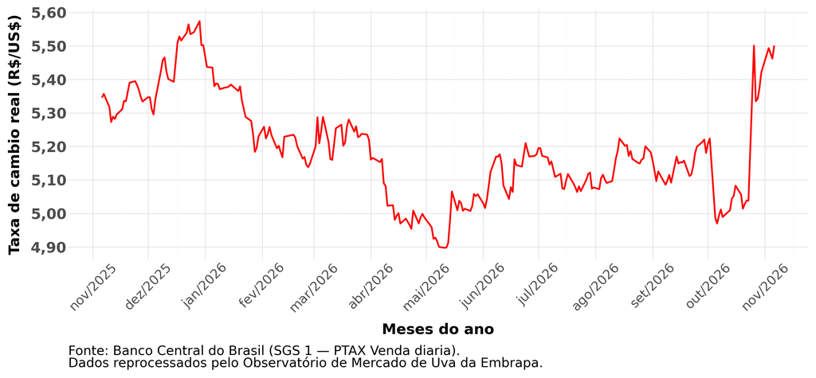

# 10. Evolução da Taxa de Câmbio Esperada para Dezembro de 2026

**GRÁFICO**

[interactive chart not shown]

Fonte: FOCUS/BCB reprocessado pelo Observatório de Mercado de Uva da Embrapa

**TABELA**

**VISUALIZAÇÃO DOS DADOS EM TABELA**

|  | Data | Taxa de Câmbio R$/US$ |
| --- | --- | --- |
| 1 | 30/10/2026 | 5.31 |
| 2 | 29/10/2026 | 5.09 |
| 3 | 28/10/2026 | 5.08 |
| 4 | 27/10/2026 | 5.07 |
| 5 | 26/10/2026 | 5.06 |
| 6 | 23/10/2026 | 5.05 |
| 7 | 22/10/2026 | 5.09 |
| 8 | 21/10/2026 | 5.09 |
| 9 | 20/10/2026 | 5.09 |
| 10 | 19/10/2026 | 5.09 |

[output cut: 198 more lines]

# INFORMAÇÕES E APOIO

[figure not shown]

João Ricardo F. de Lima

Email Coordenador: joao.ricardo@embrapa.br

https://www.embrapa.br/web/semiarido/observatorio-da-uva

[Dashboard Mercado de Uva](https://bit.ly/3OgmyKp)

Telefones:

87-3866-3667

87-99961-5799

[figure not shown]